# DATA420 - KMeans - Distributors

Jason Pemberton

2023-11-17

# Case Study Overview

KMeans is used across many fields in a variety of cases; some examples of clustering use cases include customer segmentation, fraud detection, predicting account attrition, targeting client incentives, cybercrime identification, and delivery route optimization. The KMeans clustering algorithm is increasingly being used where businesses are trying to identify patterns and optimize service.

This example uses a simulated real world scenario. A textile company in New York state, USA, must decrease expenses by minimizing delivery costs. One way to do that is to relocate warehouses closer to their distributors. The company employs 118 distributors across the state of New York. This demonstration simulates how an operations manager could segment distributors into five clustered geographies using the KMeans function and then identify five optimal warehouse locations central to those clusters using the centroid function. The objective is to discover mapping coordinates that can be used to identify five central warehouse locations.

# Load and prepare data

The dataset is based on randomly generated names and addresses in New York state with real latitude and longitude coordinates. The dataset contains the following ten columns: id, first_name, last_name, telephone, address, city, state, zip, latitude, longitude.

```r
data <- read_csv("C:/Users/jason/OneDrive/SAIT/SAIT Instructor/2023-2024/FALL 2023 - COURSE - NEW_SAIT_DATA420/data/DistributorData.csv")
```

# Visualize data

Step 1: Visualize the latitude and longitude data uaing a scatterplot

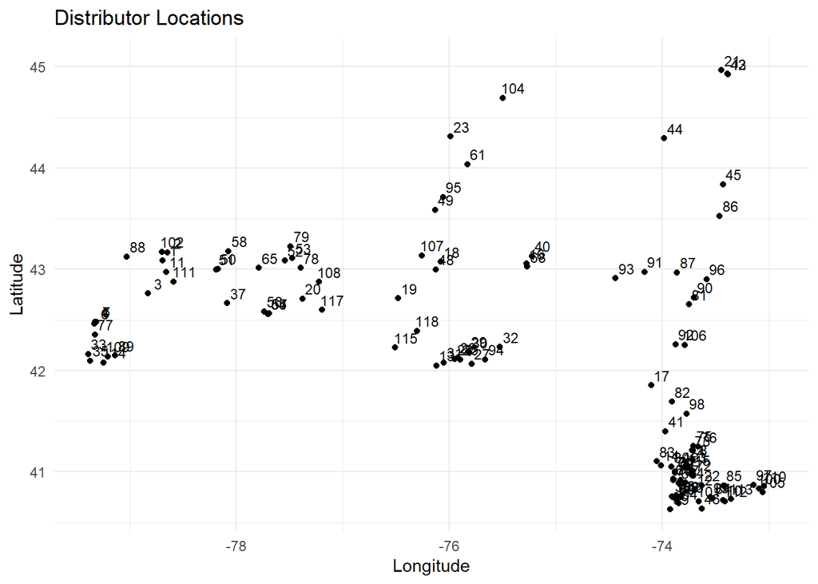

```r
data %>%
  ggplot(aes(x = longitude, y = latitude, label = id)) +
  geom_point() +
  geom_text(nudge_x = 0.1, nudge_y = 0.1, size = 3) +  # Adjust nudge values as needed
  labs(title = "Distributor Locations", x = "Longitude", y = "Latitude") +
  theme_minimal()
```

# K-Means Clustering

Apply k-means clustering to the geospatial data columns with a k value of 5 (the number of distribution centres the company wishes to build). We will create a new column in the dataframe called “cluster” where we will assign the cluster output from the k-means model.

```r
# Perform k-means clustering with 5 clusters
k <- 5
kmeans_result <- kmeans(data[, c("longitude", "latitude")], centers = k)

# Add cluster assignment to the data frame
data$cluster <- as.factor(kmeans_result$cluster)
```

# Visualize the model results

Now that we have run k-means, we will create a new scatterplot similar to the one we ran at the beginning. This time we will assign their cluster values to the colour attribute to see how k-means chose distribution centre optimization.

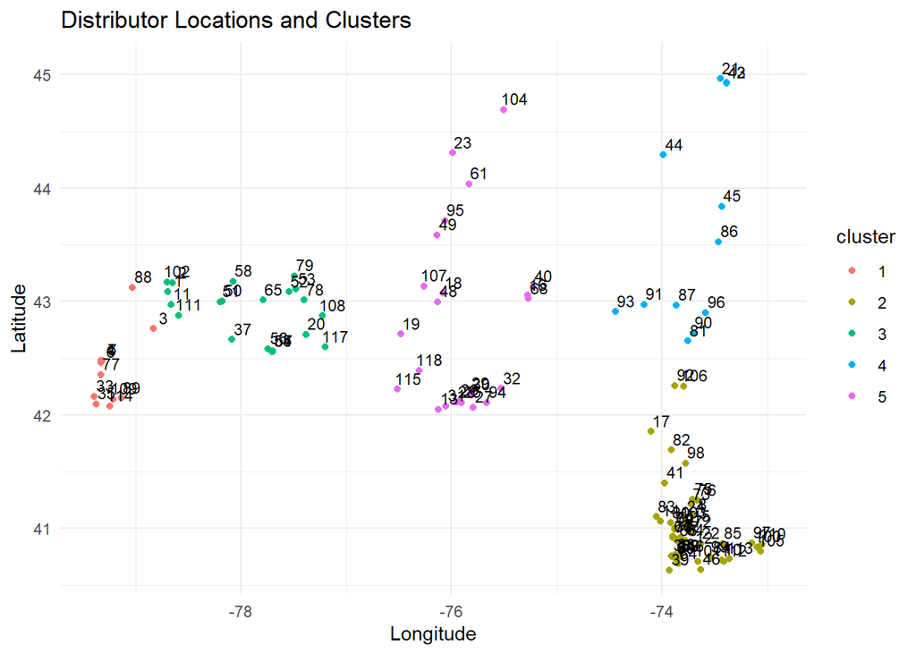

```r
# Create a scatterplot with coloured points based on clusters
ggplot(data, aes(x = longitude, y = latitude, label = id, color = cluster)) +
  geom_point() +
  geom_text(nudge_x = 0.1, nudge_y = 0.1, size = 3, col="black") +
  labs(title = "Distributor Locations and Clusters", x = "Longitude", y = "Latitude") +
  theme_minimal()
```

# Visualize the cluster distribution

We can also look at the distribution of cluster assignments using a bar chart.

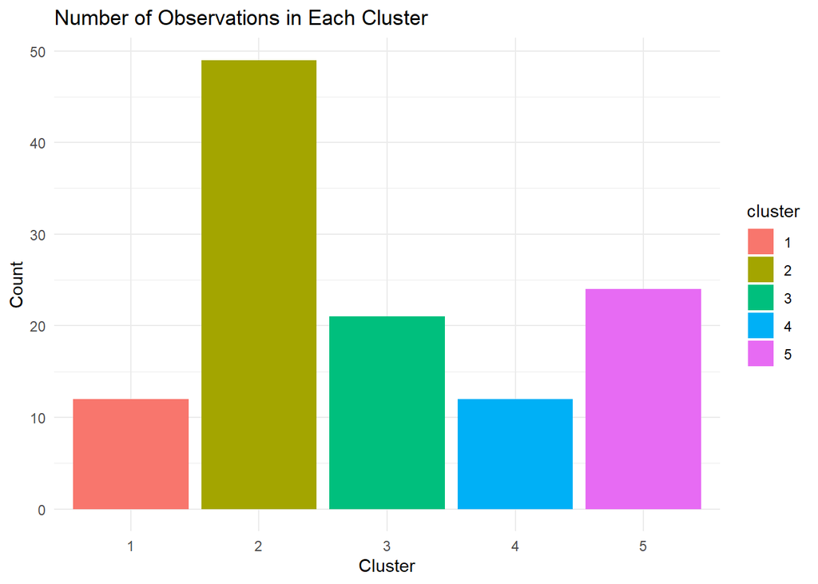

```r
# Create a bar chart showing the number of observations in each cluster
ggplot(data, aes(x = cluster, fill = cluster)) +
  geom_bar() +
  labs(title = "Number of Observations in Each Cluster", x = "Cluster", y = "Count") +
  theme_minimal()
```

# Mapping distributors and centroids

Finally we will use the leaflet package to visualize distribution centre locations on a map.

```r
# Create a leaflet map with data points and centroids
map <- leaflet(data) %>%
  addTiles() %>%
  addMarkers(~longitude, ~latitude, label = ~id, group = "Data Points") %>%
  addCircleMarkers(lng = kmeans_result$centers[, "longitude"],
                   lat = kmeans_result$centers[, "latitude"],
                   label = as.character(1:k),
                   group = "Centroids",
                   color = "blue",  # Customize the color of centroids
                   radius = 10)     # Customize the size of centroids

# Add layer control to toggle on/off data points and centroids
map <- map %>%
  addLayersControl(overlayGroups = c("Data Points", "Centroids"),
                   options = layersControlOptions(collapsed = FALSE))

# Print the map
map
```

[interactive chart not shown]